# An R wrapper for ‘An atlas of genetic correlations across human diseases and traits’

Alexander Ploner

2016-09-29

Abstract

In a recent publication[1], Bulik-Sullivan and co-authors presented a matrix of genome-wide genetic correlations derived via linkage-disequilibrium regression[2]. The resulting correlations are available both from the supplementary material of the original article and from github[3] in an easily readable, alas somewhat dry text format (.csv). This package wraps the data and offers simple, but hopefully convenient methods for extracting and displaying correlations for the whole collection or user-specified subsets thereof.

## Data extraction

### Data and data availability

The package contains a local copy of the data, but includes also a reading function to (re-) download the data.

Local copy:

```r
library(GeneCorrAtlas)
head(gcatlas)
```

```
##   Trait1          Trait2     rg      se      z     p
## 1   ADHD Age at Menarche -0.153 0.08218 -1.858 0.063
## 2   ADHD  Age at Smoking -0.036 0.24270 -0.147 0.883
## 3   ADHD     Alzheimer's -0.055 0.21910 -0.249 0.803
## 4   ADHD        Anorexia  0.192 0.11620  1.649 0.099
## 5   ADHD Autism Spectrum -0.164 0.14380 -1.144 0.253
## 6   ADHD             BMI  0.287 0.08913  3.222 0.001
```

Same as the remote copy (on Github):

```r
mygc = read_gcatlas()
all.equal(gcatlas, mygc)
```

```
## [1] TRUE
```

### Selecting a subset of traits

Often we are only interested in a subset of the traits. Function `sel_trt` allows selection of a subset, specifying only abbreviated trait names. Note that these abbreviations are interpreted generously, and you have to take extra steps to enforce unique matches.

List all trait names:

```r
traits()
```

```
##  [1] "ADHD"                      "Age at Menarche"
##  [3] "Age at Smoking"            "Alzheimer's"
##  [5] "Anorexia"                  "Autism Spectrum"
##  [7] "BMI"                       "BMI 2010"
##  [9] "Bipolar"                   "Birth Length"
## [11] "Birth Weight"              "Childhood IQ"
## [13] "Childhood Obesity"         "Cigarettes per Day"
## [15] "College"                   "Coronary Artery Disease"
## [17] "Crohn's Disease"           "Depression"
## [19] "Ever/Never Smoked"         "Extreme BMI"
## [21] "Extreme Height"            "Fasting Glucose"
## [23] "Fasting Insulin"           "Fasting Proinsulin"
## [25] "Former/Current Smoker"     "HDL"
## [27] "HOMA-B"                    "HOMA-IR"
## [29] "HbA1C"                     "Height"
## [31] "Height 2010"               "Hip Circumference"
## [33] "Infant Head Circumference" "LDL"
## [35] "Lumbar Spine BMD"          "Neck BMD"
## [37] "Obesity Class 1"           "Obesity Class 2"
## [39] "Obesity Class 3"           "Overweight"
## [41] "Rheumatoid Arthritis"      "Schizophrenia"
## [43] "T2D"                       "Total Cholesterol"
## [45] "Triglycerides"             "Ulcerative Colitis"
## [47] "Waist Circumference"       "Waist-Hip Ratio"
## [49] "Years of Education"
```

Select some interesting looking traits, but do not spell them out:

```r
sel_trt("Alz", "ADHD", "Bip", "Schizo")
```

```
##          Trait1        Trait2     rg      se      z         p
## 3          ADHD   Alzheimer's -0.055 0.21910 -0.249 8.030e-01
## 8          ADHD       Bipolar  0.265 0.15390  1.722 8.500e-02
## 41         ADHD Schizophrenia  0.232 0.08871  2.617 9.000e-03
## 146 Alzheimer's       Bipolar -0.011 0.09051 -0.126 9.000e-01
## 179 Alzheimer's Schizophrenia  0.036 0.06459  0.552 5.810e-01
## 389     Bipolar Schizophrenia  0.794 0.03862 20.552 7.447e-94
```

Alternatively, we can specify a vector of names; this is often easier when working non-interactively:

```r
shortlist = traits()[1:5]
shortlist
```

```
## [1] "ADHD"            "Age at Menarche" "Age at Smoking"  "Alzheimer's"
## [5] "Anorexia"
```

```r
sel_trt(shortlist)
```

```
##              Trait1          Trait2     rg      se      z      p
## 1              ADHD Age at Menarche -0.153 0.08218 -1.858 0.0630
## 2              ADHD  Age at Smoking -0.036 0.24270 -0.147 0.8830
## 3              ADHD     Alzheimer's -0.055 0.21910 -0.249 0.8030
## 4              ADHD        Anorexia  0.192 0.11620  1.649 0.0990
## 49  Age at Menarche  Age at Smoking  0.041 0.08837  0.465 0.6419
## 50  Age at Menarche     Alzheimer's -0.016 0.06840 -0.236 0.8134
## 51  Age at Menarche        Anorexia  0.026 0.04347  0.605 0.5452
## 96   Age at Smoking     Alzheimer's  0.101 0.22240  0.455 0.6490
## 97   Age at Smoking        Anorexia  0.148 0.15410  0.961 0.3360
## 142     Alzheimer's        Anorexia  0.109 0.11520  0.950 0.3420
```

Note that `sel_trt` accepts partial and multiple matches:

```r
sel_trt("BMI", "Height")
```

```
##             Trait1         Trait2     rg       se       z         p
## 274            BMI       BMI 2010  1.013 0.006687 151.438 0.000e+00
## 286            BMI    Extreme BMI  1.027 0.025440  40.373 0.000e+00
## 287            BMI Extreme Height -0.090 0.033380  -2.707 6.781e-03
## 296            BMI         Height -0.093 0.020600  -4.516 6.295e-06
## 297            BMI    Height 2010 -0.094 0.024180  -3.896 9.777e-05
## 327       BMI 2010    Extreme BMI  1.021 0.020170  50.629 0.000e+00
## 328       BMI 2010 Extreme Height -0.083 0.036750  -2.253 2.426e-02
## 337       BMI 2010         Height -0.084 0.024130  -3.474 5.129e-04
## 338       BMI 2010    Height 2010 -0.092 0.028040  -3.297 9.774e-04
## 742    Extreme BMI Extreme Height -0.117 0.043610  -2.689 7.161e-03
## 751    Extreme BMI         Height -0.105 0.030850  -3.409 6.510e-04
## 752    Extreme BMI    Height 2010 -0.106 0.036650  -2.905 3.677e-03
## 779 Extreme Height         Height  0.992 0.015520  63.942 0.000e+00
## 780 Extreme Height    Height 2010  0.983 0.014880  66.042 0.000e+00
## 987         Height    Height 2010  1.010 0.004409 229.100 0.000e+00
```

If we want to have unique matches, we need to specify a proper regular expression, like so:

```r
sel_trt("^BMI$", "^Height$")
```

```
##     Trait1 Trait2     rg     se      z         p
## 296    BMI Height -0.093 0.0206 -4.516 6.295e-06
```

Extras: `sel_trt` has a `drop`-argument, so that the specified matches are dropped from the data rather than retained; and while it operates by default on the full atlas of genetic correlations, we can use the `data` argument to select from a subset. Below, we drop all traits that contain `BMI` in their name in the first step, then we select from resulting subset:

```r
sub1 = sel_trt("BMI", drop=TRUE)
traits(sub1)
```

```
##  [1] "ADHD"                      "Age at Menarche"
##  [3] "Age at Smoking"            "Alzheimer's"
##  [5] "Anorexia"                  "Autism Spectrum"
##  [7] "Bipolar"                   "Birth Length"
##  [9] "Birth Weight"              "Childhood IQ"
## [11] "Childhood Obesity"         "Cigarettes per Day"
## [13] "College"                   "Coronary Artery Disease"
## [15] "Crohn's Disease"           "Depression"
## [17] "Ever/Never Smoked"         "Extreme Height"
## [19] "Fasting Glucose"           "Fasting Insulin"
## [21] "Fasting Proinsulin"        "Former/Current Smoker"
## [23] "HDL"                       "HOMA-B"
## [25] "HOMA-IR"                   "HbA1C"
## [27] "Height"                    "Height 2010"
## [29] "Hip Circumference"         "Infant Head Circumference"
## [31] "LDL"                       "Lumbar Spine BMD"
## [33] "Neck BMD"                  "Obesity Class 1"
## [35] "Obesity Class 2"           "Obesity Class 3"
## [37] "Overweight"                "Rheumatoid Arthritis"
## [39] "Schizophrenia"             "T2D"
## [41] "Total Cholesterol"         "Triglycerides"
## [43] "Ulcerative Colitis"        "Waist Circumference"
## [45] "Waist-Hip Ratio"           "Years of Education"
```

```r
sel_trt("Alz", "Bip", "T2D", data=sub1)
```

```
##          Trait1  Trait2     rg      se      z      p
## 146 Alzheimer's Bipolar -0.011 0.09051 -0.126 0.9000
## 180 Alzheimer's     T2D -0.021 0.12720 -0.168 0.8660
## 390     Bipolar     T2D -0.164 0.07077 -2.313 0.0207
```

### Extracting a (correlation-) matrix

In many situations it is more convenient to look at the actual matrix of genetic correlation coefficients instead of the more efficient lower triangular format they are provided in. The function `gcmatrix` returns a symmetric matrix of either correlation coefficients (the default), their standard errors, the corresponding z-statistics or p-values; these are for example the upper five rows and columns of the full correlation matrix:

```r
gcmatrix()[1:5, 1:5]
```

```
##                   ADHD Age at Menarche Age at Smoking Alzheimer's Anorexia
## ADHD             1.000          -0.153         -0.036      -0.055    0.192
## Age at Menarche -0.153           1.000          0.041      -0.016    0.026
## Age at Smoking  -0.036           0.041          1.000       0.101    0.148
## Alzheimer's     -0.055          -0.016          0.101       1.000    0.109
## Anorexia         0.192           0.026          0.148       0.109    1.000
```

By default, the full matrix is returned (and was just truncated above to save space); we can however specify instead any subset of the full data that corresponds to a sub-matrix of the full matrix. Luckily (?), this is exactly what `sel_trt` returns:

```r
gcmatrix(sel_trt("Depr", "Schiz", "Bipo", "ADHD", "Alz"))
```

```
##                 ADHD Alzheimer's Bipolar Depression Schizophrenia
## ADHD           1.000      -0.055   0.265     0.2360        0.2320
## Alzheimer's   -0.055       1.000  -0.011     0.0730        0.0360
## Bipolar        0.265      -0.011   1.000     0.4780        0.7940
## Depression     0.236       0.073   0.478     1.0000        0.5083
## Schizophrenia  0.232       0.036   0.794     0.5083        1.0000
```

If we want to study a matrix of standard errors etc. instead of the genetic correlations, we can specify this via the `type`-argument:

```r
gcmatrix(sel_trt("Depr", "Schiz", "Bipo", "ADHD", "Alz"), type="p")
```

```
##                ADHD Alzheimer's   Bipolar Depression Schizophrenia
## ADHD             NA       0.803 8.500e-02  2.150e-01     9.000e-03
## Alzheimer's   0.803          NA 9.000e-01  6.290e-01     5.810e-01
## Bipolar       0.085       0.900        NA  6.572e-06     7.447e-94
## Depression    0.215       0.629 6.572e-06         NA     1.319e-11
## Schizophrenia 0.009       0.581 7.447e-94  1.319e-11            NA
```

## Graphical display

### Overview of a correlation matrix

The function `gcheatmap` provides a clustered heatmap, by default of all traits in the full data set.

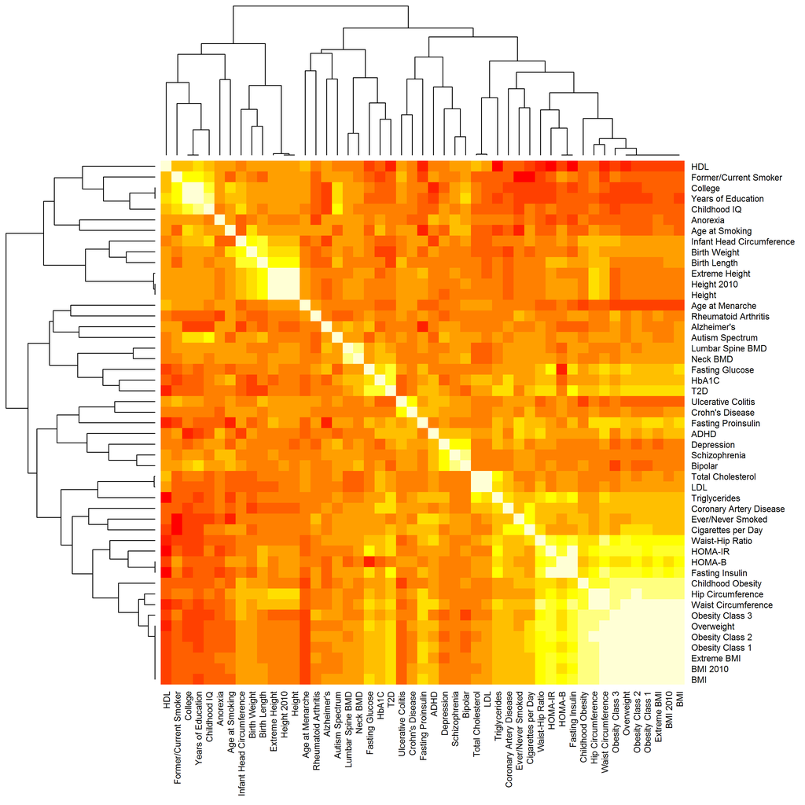

```r
gcheatmap()
```

We can of course use the `sel_trt` function to zoom in on specific subsets of traits. E.g. below, we see two clearly separated clusters of traits, one related to obesity/BMI, the other to overall length. Noteably, underlying genetic drivers for birth length and -weight are more closely related to adult height than obesity, but form a distinct subcluster of their own among the height/length variables.

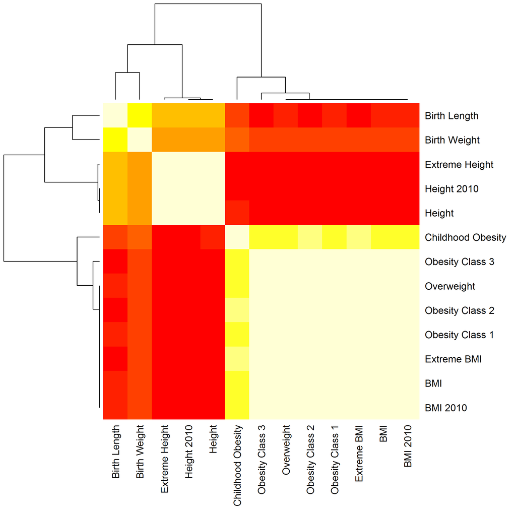

```r
gcheatmap(sel_trt(c("BMI", "Obesity", "Overweight", "Height", "Birth")))
```

### Display of all correlations for one trait

We can easily plot all correlations with a specific trait of interest, with confidence intervals; by default, the correlations are sorted by size:

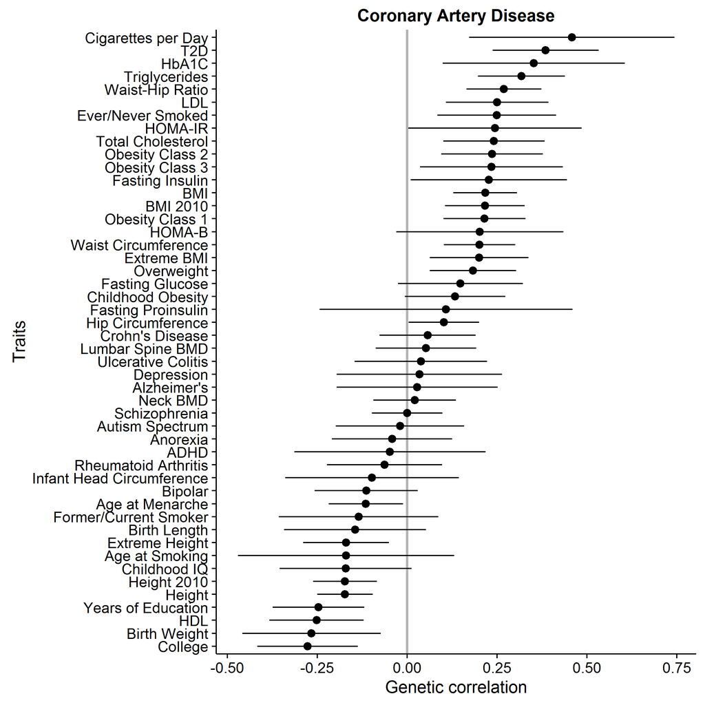

```r
plotTrait("Cor")
```

Note that while we still can abbreviate the trait name, the specification must be unique, otherwise the function throws an error. On the other hand, we can again provide a `data`-argument if we only want to show correlations with a subsets of traits:

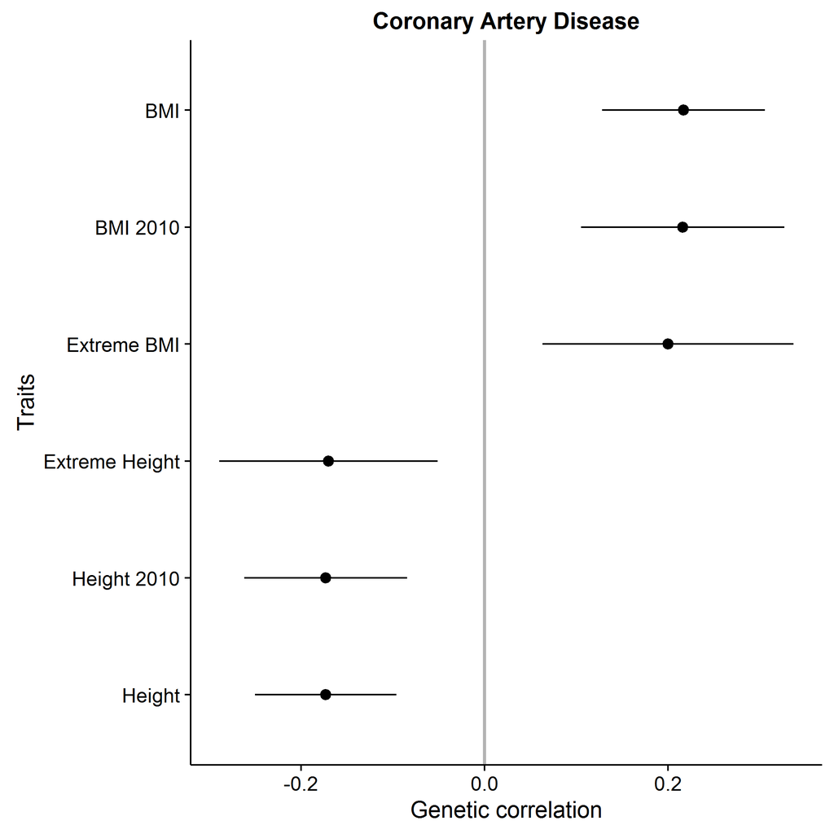

```r
plotTrait("Cor", sel_trt("BMI", "Height", "Cor"))
```

### Comparison correlation patterns for two traits

We can also create a scatterplot of genetic correlations for any pair of traits. Effectively, this is a scatter plot of two columns in the full genetic correlation matrix against each other. We find for example in the plot below that both depression (horizontal axis) and bipolar disorder (vertical axis) show strong genetic correlation with schizophrenia, and mild to moderate negative correlation with obesity. We also find that bipolar disorder is moderately positively correlated with age at smoking, college attendance, years of education, neck bone mass desnity and ADHD, while depression shows a range of correlations with these traits.

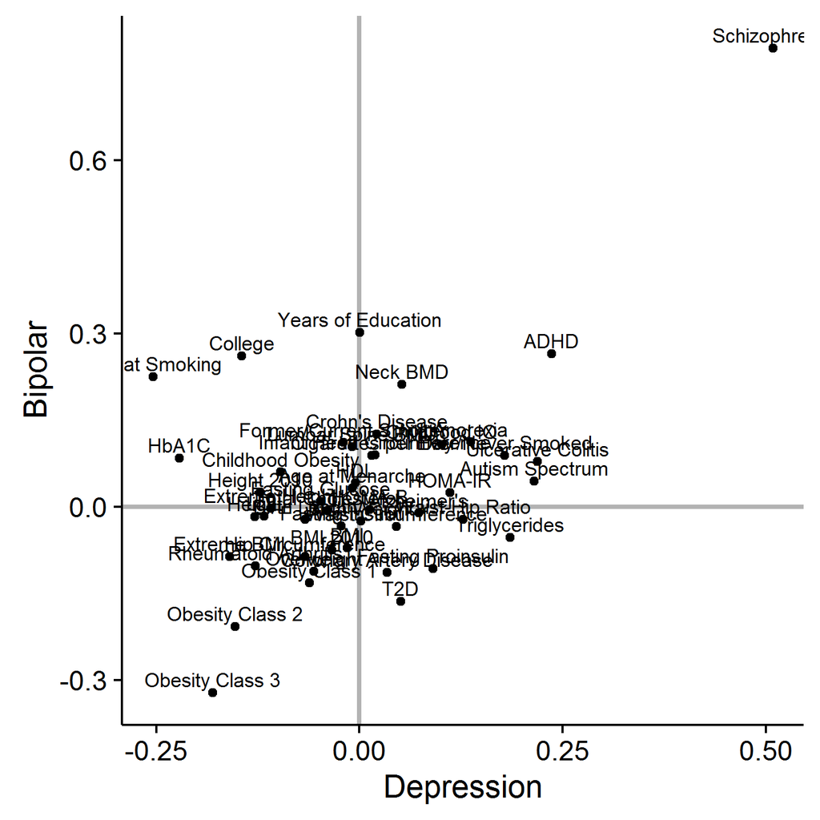

```r
plotPairedTraits("Depression", "Bipolar")
```

One problem with this scatterplot is that it can get crowded and hard to read. For this situation, we can provide a significance level via the argument `co`, so that correlations that do not reach this level of significance are grayed out, while the statistically significant correlations are color- and symbol-coded: red triangles for significant correlation with the trait on the x-axis, blue dots for sígnificant correlation with the trait on the y-axis, and purple squares if a trait is signicantly correlated with both x- and y-trait:

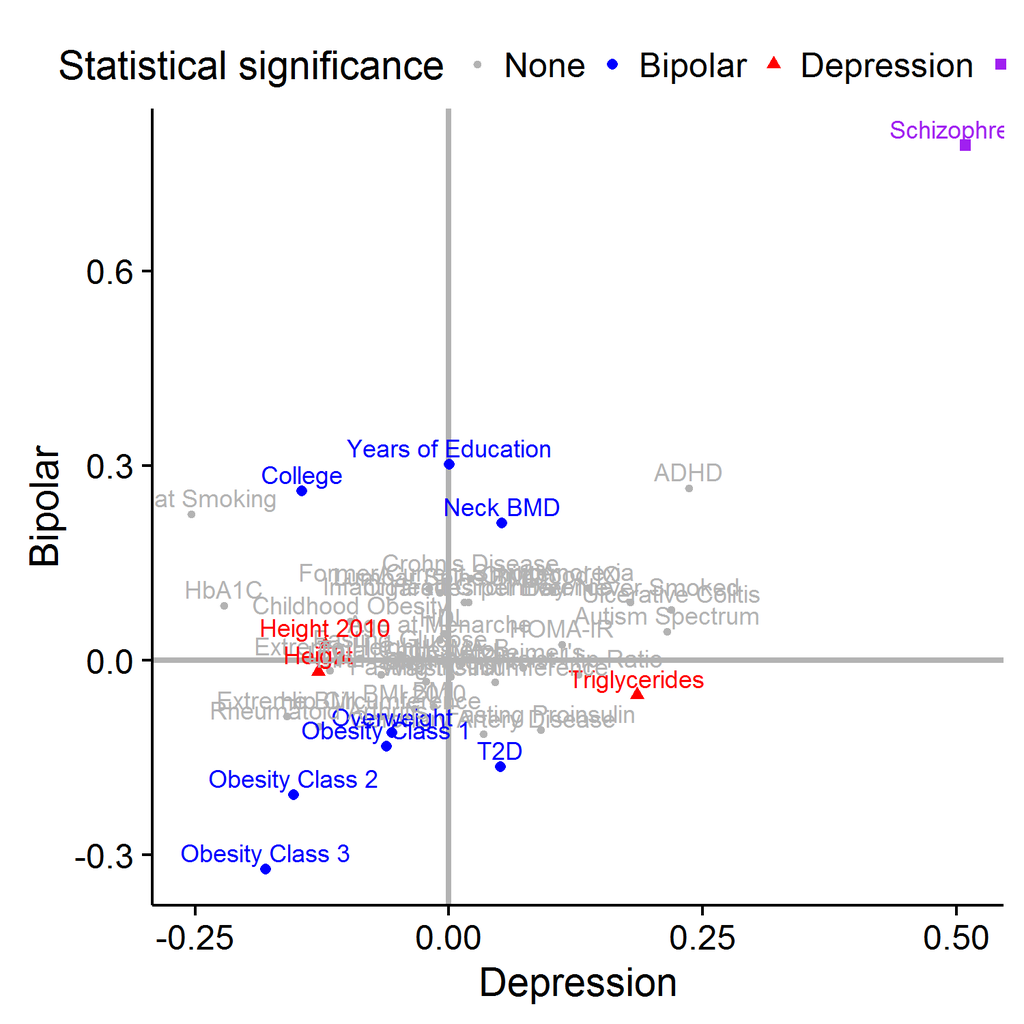

```r
plotPairedTraits("Depression", "Bipolar", co=0.05)
```

We find that only the association with schizophrenia is significantly associated with both depression and bipolar disorder. In addition, despression is significantly associated with triglycerides (positively) and height (negatively); bipolar disorder is positively associated with college attendance, years of education, and neck bone mass density, and negatively with obesity, overweight and type 2 diabetes.

## References

1. Bulik-Sullivan, Brendan, Hilary K Finucane, Verneri Anttila, Alexander Gusev, Felix R Day, ReproGen Consortium, Psychiatric Genomics Consortium, et al. ‘An Atlas of Genetic Correlations across Human Diseases and Traits’, 27 January 2015. http://biorxiv.org/lookup/doi/10.1101/014498.
2. Bulik-Sullivan, Brendan K., Po-Ru Loh, Hilary K. Finucane, Stephan Ripke, Jian Yang, Schizophrenia Working Group of the Psychiatric Genomics Consortium, Nick Patterson, Mark J. Daly, Alkes L. Price, and Benjamin M. Neale. ‘LD Score Regression Distinguishes Confounding from Polygenicity in Genome-Wide Association Studies’. Nature Genetics 47, no. 3 (March 2015): 291-95. doi:10.1038/ng.3211.
3. https://raw.githubusercontent.com/bulik/gencor/master/all_rg.csv